# Data transformations

17 April 2026

## Goals for today

- Identify possible transformations of the response variable when your errors have unequal variance or are skewed
- Understand how to use common transformations and make inference from the resulting model
- Understand that there are alternatives to transformation that we will use later

## Why would you transform?

We have made a number of assumptions about our models, which include

- the distribution of the errors (IID)
- linear relationship(s) between the response and predictor(s)

What can we do when these assumptions are not met?

## What can you transform?

It’s possible to transform either or both sides of our models to

- achieve constant variance \(\rightarrow\) transform \(y\)
- correct for skewness \(\rightarrow\) transform \(y\)
- linearize the relationship \(\rightarrow\) transform \(x\) and/or \(y\)

## Types of transformations

The most common form is where \(y^* = y^\lambda\)

and \(\lambda > 1\) (powers)

or \(0 < \lambda < 1\) (roots)

For example

\(\lambda = 2 \Rightarrow y^* = y^2\)

\(\lambda = \frac{1}{2} \Rightarrow y^* = \sqrt{y}\)

## Types of transformations

One can also use inverses where \(y^* = y^{-\lambda}\)

and \(\lambda > 1\) (powers)

or \(0 < \lambda < 1\) (roots)

For example

\(\lambda = 2 \Rightarrow y^* = \frac{1}{y^2}\)

\(\lambda = \frac{1}{2} \Rightarrow y^* = \frac{1}{\sqrt{y}}\)

## Box-Cox transformation

The Box-Cox transformation is popular for stabilizing the variance of errors

It is defined as

\[ y^* = \frac{y^{\lambda} - 1}{\lambda} \]

for all \(y > 0\)

## Box-Cox transformation

More specifically, because

\[ \lim\limits_{\lambda \to 0} \frac{y^{\lambda} - 1}{\lambda} = \log(y) \]

we instead use

\[ y^* = \left\{ \begin{matrix} \frac{y^{\lambda} - 1}{\lambda} ~ \text{if} ~ \lambda \neq 0 \\ \log(y) ~ \text{if} ~ \lambda = 0 \end{matrix} \right. \]

## Box-Cox transformation

How does one actually *choose* \(\lambda\)?

By using *profile likelihoods* (which we will see in a later lecture)

We’ll use the `boxcox()` function from the **{MASS}** package

## Box-Cox transformation

### An example

Let’s return to the plant data from the Galapagos Archipelago where we modeled diversity as a function of island area

```r
## get data
data(gala, package = "faraway")
## fit regression model
mm <- lm(Species ~ Area, gala)
## estimate lambda
MASS::boxcox(mm)
```

## Box-Cox transformation

Here is the result of calling `boxcox(mm)`

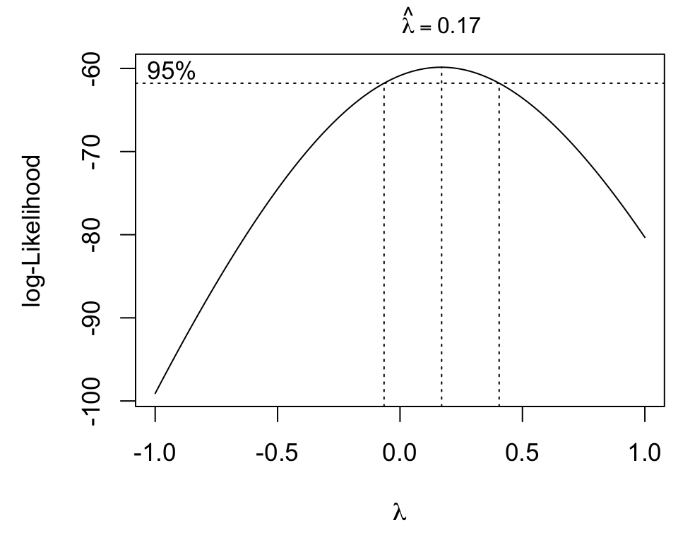

## Box-Cox transformation

Okay, so how do we interpret \(\lambda = 0.17\)?

Box-Cox transformations work well, but sometimes we can do better with an approximation to \(\lambda\)

## Box-Cox transformation

General considerations

- The Box–Cox method gets upset by outliers

For example, if \(\hat{\lambda}\) = 5 there is little rationale for such an extreme transformation

## Box-Cox transformation

General considerations

- The Box–Cox method gets upset by outliers
- If some \(y_i\) < 0, we can add a constant to all the \(y\)

This works if the constant is small, but it’s a “hack”

## Box-Cox transformation

General considerations

- The Box–Cox method gets upset by outliers
- If some \(y_i\) < 0, we can add a constant to all the \(y\)
- If the range in \(y\) is small, then the Box–Cox transformation has little effect

Recall that linear models work well for *local* non-linear functions

## Alternative to Box-Cox

Consider the fecundity of a fish versus its length

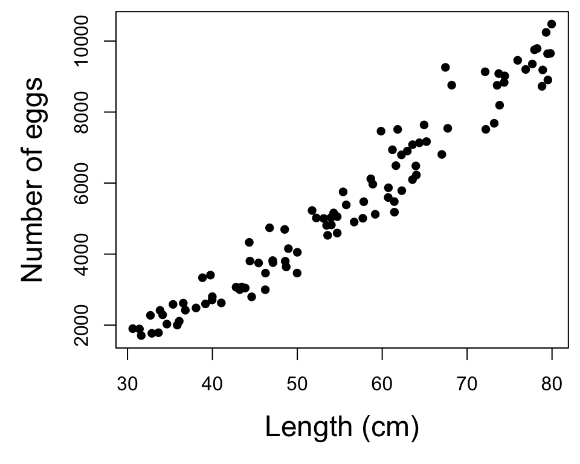

## Alternative to Box-Cox

Here’s the fit from a linear regression

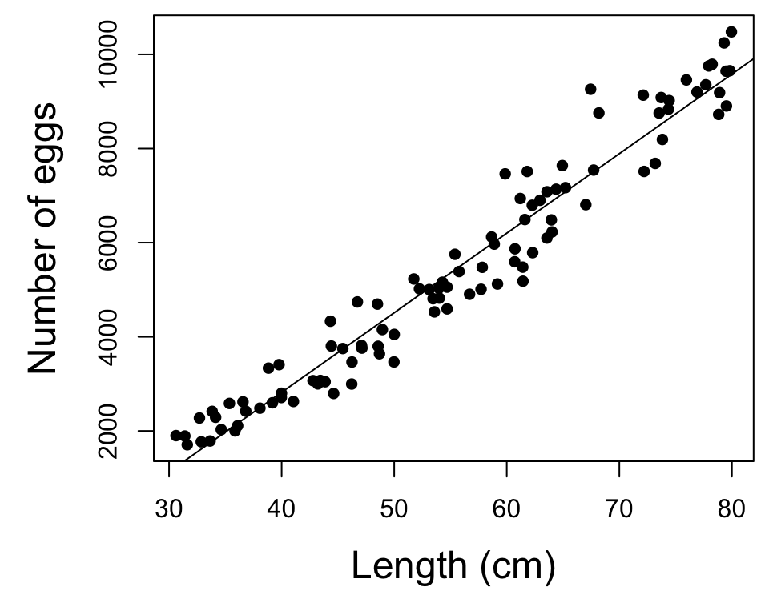

## Alternative to Box-Cox

And here are the residuals from the fitted model

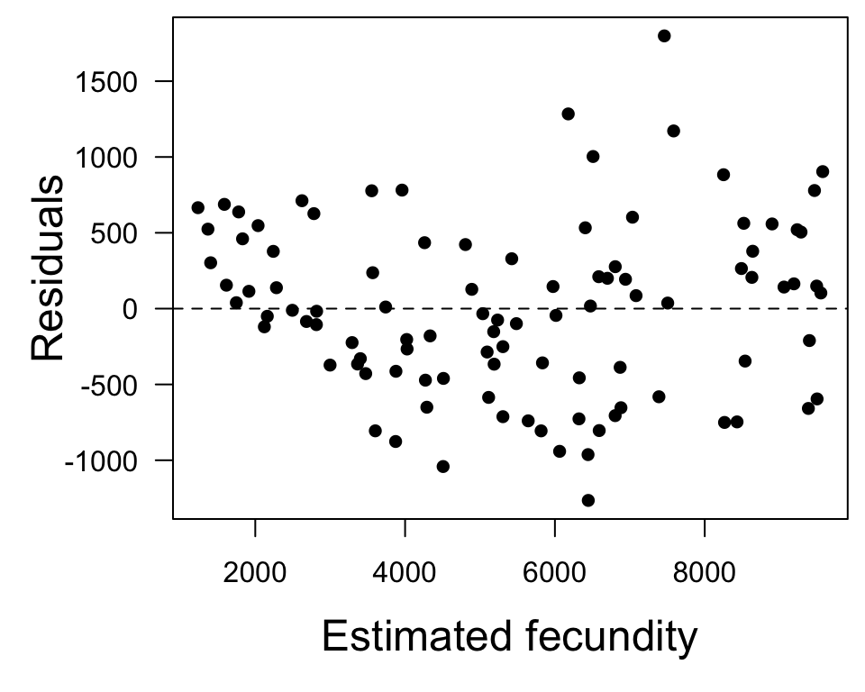

## Alternative to Box-Cox

This \(\hat{\lambda}\) is really close to 0.5 which is a square-root transform \((x^\frac{1}{2} = \sqrt{x})\)

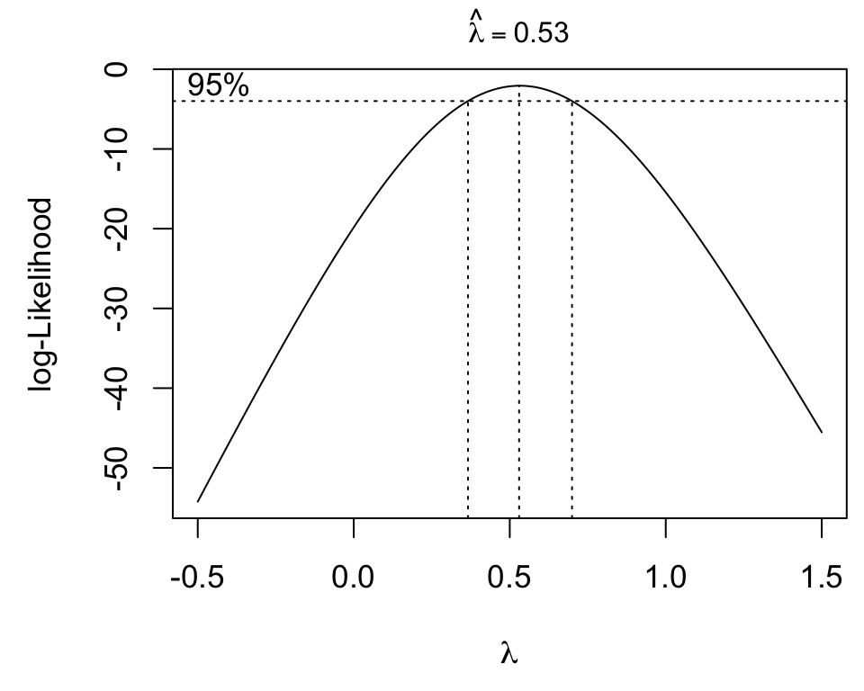

## Square root transformation

Here’s the fit from a linear regression to \(\sqrt{y}\)

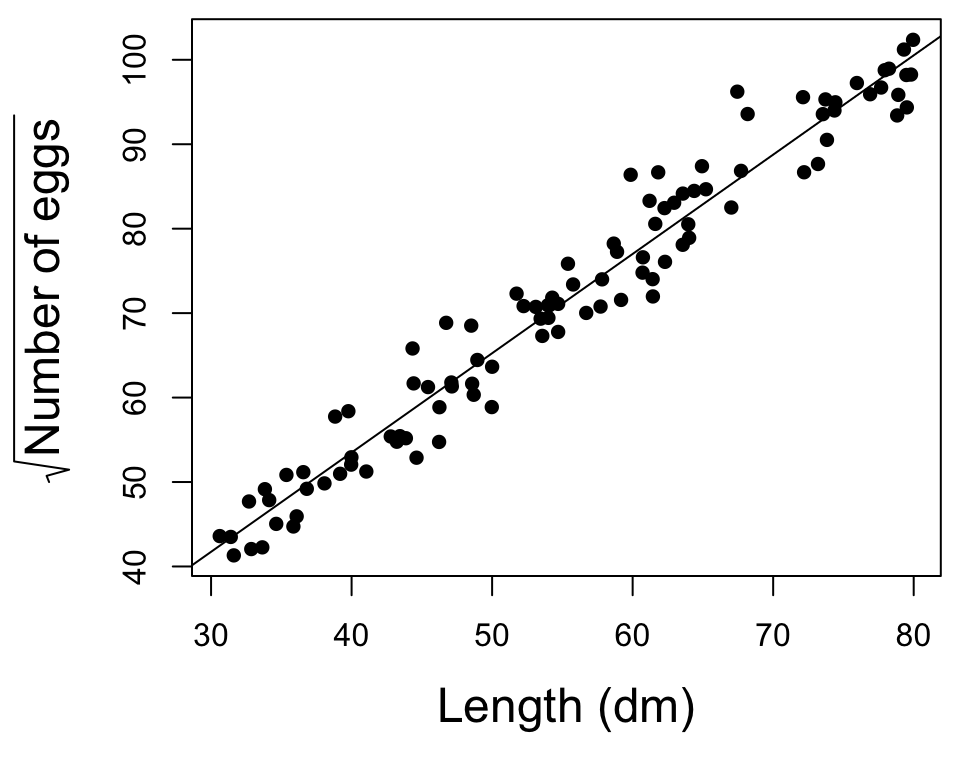

## Square root transformation

And here are the residuals from the fitted model

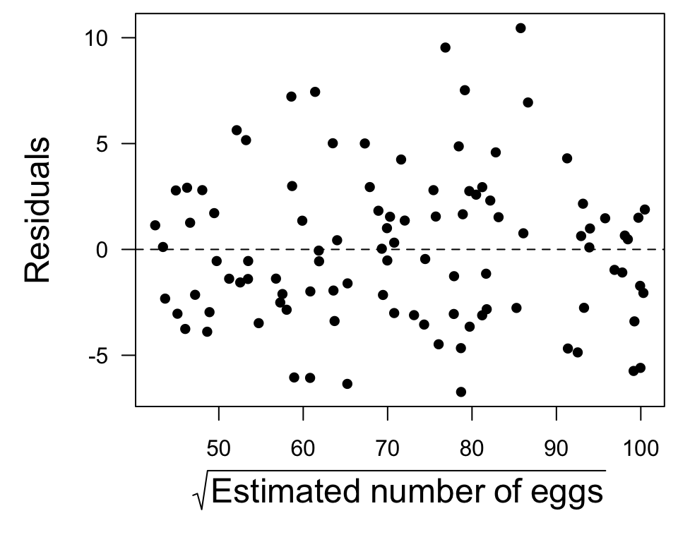

## Predictions from a transformed model

Using `predict()` will give fitted values \((\hat{y})\) on the transformed scale

```r
## expected sqrt(fecundity) for length = 5 dm
predict(ms, data.frame(ll = 5), interval = "confidence")
```

```
##        fit      lwr      upr
## 1 12.33559 9.723902 14.94727
```

## Predictions from a transformed model

We need to include the back-transformation on `predict()`

\[ \begin{aligned} \sqrt{\hat{y}}_i &= x_i \hat{\boldsymbol{\beta}} \\ &\Downarrow \\ \hat{y}_i &= (x_i \hat{\boldsymbol{\beta}})^2 \\ \end{aligned} \]

## Back-transformed fit

Here are the fitted values and prediction interval on the natural scale

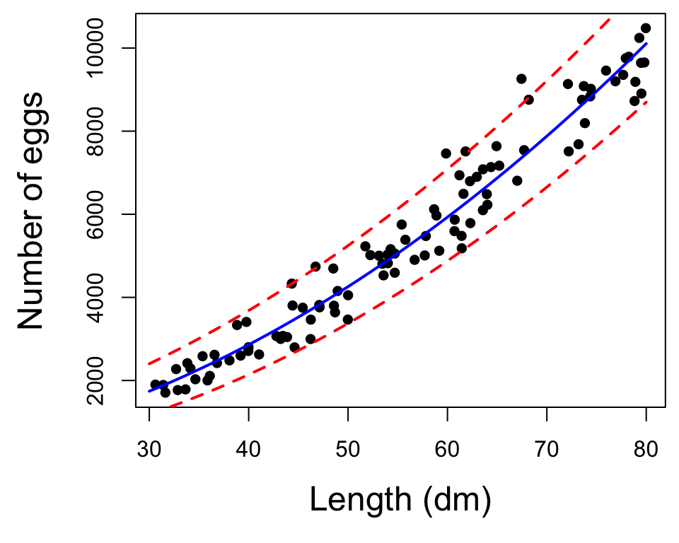

## Transformed polynomials

Think back to an early lecture where we transformed a nonlinear polynomial into a linear model

\[ y_i = \beta_0 + \beta_1 x_{1,i} + \beta_2 \color{blue}{x_{2,i}^2} + e_i \\ \Downarrow \\ y_i = \beta_0 + \beta_1 x_{1,i} + \beta_2 \color{blue}{z_{2,i}} + e_i \\ \color{blue}{z_{2,i}} = \color{blue}{x_{2,i}^2} \]

## Transformed polynomials

Polynomials are an easy way to model nonlinearities in data, such as

- Seasonal effects on primary productivity
- Temperature effects on growth of poikilotherms

## Ecological data

Many ecological observations only take positive values \((y > 0)\)

- length or mass
- fecundity
- species counts/density
- concentration
- latency periods for infectious diseases

The distributions of these data also tend to be “long-tailed”

## Long-tailed data

Distribution of plant diversity data in the `gala` dataset

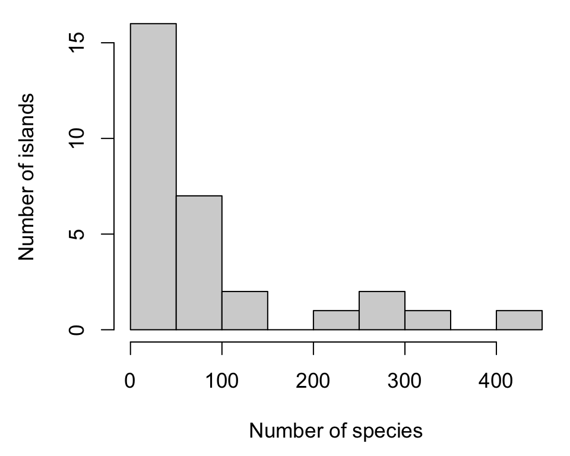

## Long-tailed data

These long-tailed data often follow a log-normal distribution

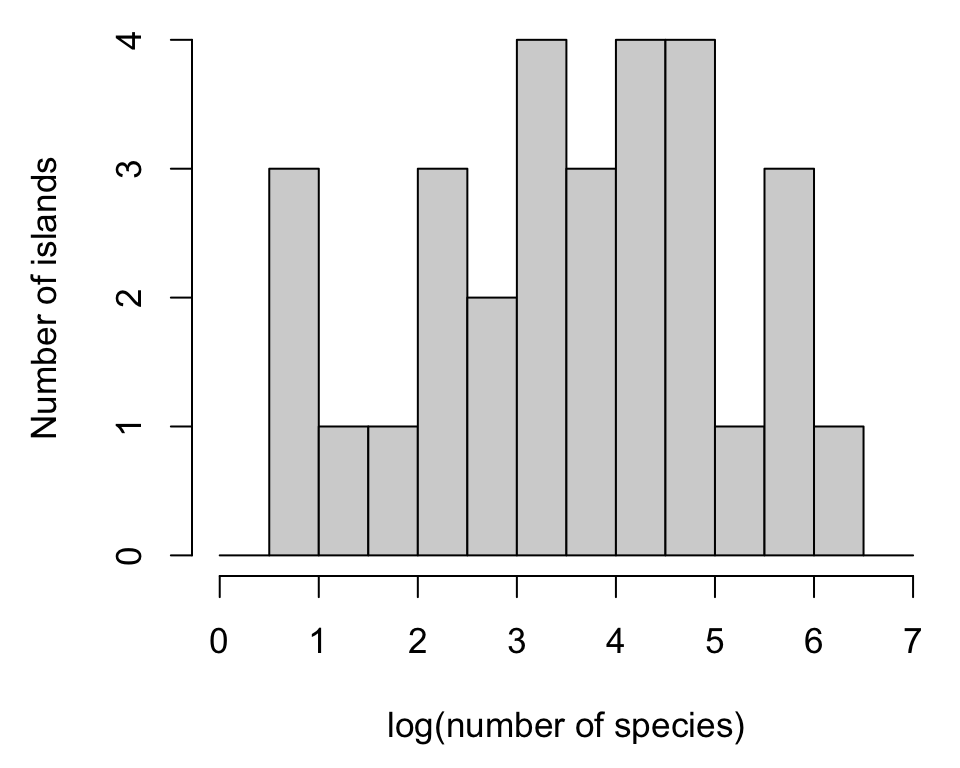

## Log transformation

A log-transformation is a really common way to deal with ecological data that are constrained to be positive

\[ y_i = \exp(\beta_0 + \beta_1 x_{i} + e_i) \\ \Downarrow \\ \log(y_i) = \beta_0 + \beta_1 x_{i} + e_i \]

## Log-log transformation

Consider allometric scaling laws in ecology of the form

\[ y_i = \alpha \cdot x_i^\beta \cdot \delta_i \]

For example, body mass as a function of length

## Log-log transformation

Log-log transformations are an easy way to linearize power models

\[ m_i = \alpha \cdot l_i^\beta \cdot \delta_i \\ \Downarrow \\ \log(m_i) = \log(\alpha) + \beta ~ \log(l_i) + \log(\delta_i) \\ \Downarrow \\ y_i = \beta_0 + \beta_1 x_i + e_i \]

## Linear model for size of fish

The response and predictor are linear on the log-log scale

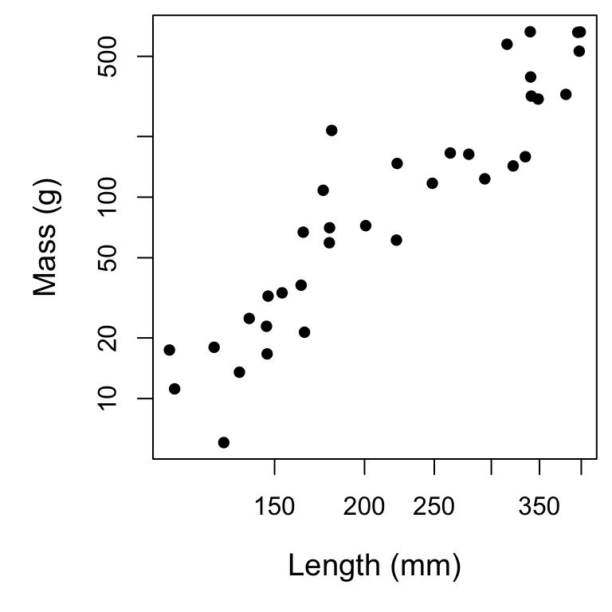

## Summary

- Box-Cox is good to help ID a power/root, but the transformed variable can be hard to interpret
- \(\sqrt{y}\) is good for equalizing variance
- \(\log(y)\) is good for skewed data
- \(\log(y + a)\) with small \(a\) is good for skewed data with some 0’s
- We will see later that there are model alternatives to transformations (GLMs)